[Return to Portfolio Page](https://sebastianghafafian.github.io/Portfolio/)

# Analysis of Data Science Job Postings

Check out the project on [Github](https://github.com/SebastianGhafafian/EDA_Data_Science_Job_Market).

**Keywords**: EDA, Data visualization, Folium, Pandas, One-Hot Encoding, Cleaning data, word clouds

## Introduction

After four year of being an engineer I am exploring the possiblity to transition into data science. Starting out in the field of data science can be intimidating. There are alot of job postings online and the requirements vary drastically as data science is a broad field. What better way to do approach the job search utilizing the data science methodology itself to create insights about job market? In this project, a scraped data set from Glassdoor containing job postings in the field of data is cleaned and analysed for common trends and potential employers. As a resident of California, a focus is laid upon potential employers and the market in that state.

Let's import the uncleaned data set.

```python
import pandas as pd
import numpy as np
import seaborn as sns
import matplotlib.pyplot as plt
import warnings
import folium
from wordcloud import WordCloud, STOPWORDS
#settings
warnings.filterwarnings('ignore')
sns.set_theme()
```

```python
#import and first inspection of the data set
df = pd.read_csv("./data/uncleaned_jobs.csv")
df.set_index("index", inplace=True)
df.head(8)
```

| index | Job Title | Salary Estimate | Job Description | Rating | Company Name | Location | Headquarters | Size | Founded | Type of ownership | Industry | Sector | Revenue | Competitors |
| --- | --- | --- | --- | --- | --- | --- | --- | --- | --- | --- | --- | --- | --- | --- |
| 0 | Sr Data Scientist | $137K-$171K (Glassdoor est.) | Description\n\nThe Senior Data Scientist is re... | 3.1 | Healthfirst\n3.1 | New York, NY | New York, NY | 1001 to 5000 employees | 1993 | Nonprofit Organization | Insurance Carriers | Insurance | Unknown / Non-Applicable | EmblemHealth, UnitedHealth Group, Aetna |
| 1 | Data Scientist | $137K-$171K (Glassdoor est.) | Secure our Nation, Ignite your Future\n\nJoin ... | 4.2 | ManTech\n4.2 | Chantilly, VA | Herndon, VA | 5001 to 10000 employees | 1968 | Company - Public | Research & Development | Business Services | $1 to $2 billion (USD) | -1 |
| 2 | Data Scientist | $137K-$171K (Glassdoor est.) | Overview\n\n\nAnalysis Group is one of the lar... | 3.8 | Analysis Group\n3.8 | Boston, MA | Boston, MA | 1001 to 5000 employees | 1981 | Private Practice / Firm | Consulting | Business Services | $100 to $500 million (USD) | -1 |
| 3 | Data Scientist | $137K-$171K (Glassdoor est.) | JOB DESCRIPTION:\n\nDo you have a passion for ... | 3.5 | INFICON\n3.5 | Newton, MA | Bad Ragaz, Switzerland | 501 to 1000 employees | 2000 | Company - Public | Electrical & Electronic Manufacturing | Manufacturing | $100 to $500 million (USD) | MKS Instruments, Pfeiffer Vacuum, Agilent Tech... |
| 4 | Data Scientist | $137K-$171K (Glassdoor est.) | Data Scientist\nAffinity Solutions / Marketing... | 2.9 | Affinity Solutions\n2.9 | New York, NY | New York, NY | 51 to 200 employees | 1998 | Company - Private | Advertising & Marketing | Business Services | Unknown / Non-Applicable | Commerce Signals, Cardlytics, Yodlee |
| 5 | Data Scientist | $137K-$171K (Glassdoor est.) | About Us:\n\nHeadquartered in beautiful Santa ... | 4.2 | HG Insights\n4.2 | Santa Barbara, CA | Santa Barbara, CA | 51 to 200 employees | 2010 | Company - Private | Computer Hardware & Software | Information Technology | Unknown / Non-Applicable | -1 |
| 6 | Data Scientist / Machine Learning Expert | $137K-$171K (Glassdoor est.) | Posting Title\nData Scientist / Machine Learni... | 3.9 | Novartis\n3.9 | Cambridge, MA | Basel, Switzerland | 10000+ employees | 1996 | Company - Public | Biotech & Pharmaceuticals | Biotech & Pharmaceuticals | $10+ billion (USD) | -1 |
| 7 | Data Scientist | $137K-$171K (Glassdoor est.) | Introduction\n\nHave you always wanted to run ... | 3.5 | iRobot\n3.5 | Bedford, MA | Bedford, MA | 1001 to 5000 employees | 1990 | Company - Public | Consumer Electronics & Appliances Stores | Retail | $1 to $2 billion (USD) | -1 |

## 1 Data cleaning and feature engineering

This data set is dirty and most features are not analysis friendly. Let's start with the ones which are easily addressed:

1. The salary is not an integer and additional information is provided
2. The company name contains artefacts from the rating
3. The location can be split is state and city
4. The data contains inconsistent formats for unknown values ('unknown',-1,...)
5. Job titles are not uniform
6. Job titles may contain information about the level ('Sr', 'Junior') and could be extracted as features
7. Job requirements are "hidden" in unstructured feature "Job Description"
8. Number of competitors can be extracted from Competitors column

Let's start with the salary:

##### 1.1) Salary

```python
#Remove additional info for salary
df['Salary Estimate'] = df['Salary Estimate'].map(lambda x: x.split('(')[0])
df['Salary Estimate'].unique() #check result
```

```
array(['$137K-$171K ', '$75K-$131K ', '$79K-$131K ', '$99K-$132K ',
       '$90K-$109K ', '$101K-$165K ', '$56K-$97K ', '$79K-$106K ',
       '$71K-$123K ', '$90K-$124K ', '$91K-$150K ', '$141K-$225K ',
       '$145K-$225K', '$79K-$147K ', '$122K-$146K ', '$112K-$116K ',
       '$110K-$163K ', '$124K-$198K ', '$79K-$133K ', '$69K-$116K ',
       '$31K-$56K ', '$95K-$119K ', '$212K-$331K ', '$66K-$112K ',
       '$128K-$201K ', '$138K-$158K ', '$80K-$132K ', '$87K-$141K ',
       '$92K-$155K ', '$105K-$167K '], dtype=object)
```

All that's left is to extract the numerical values for the minimum, maximum and mean:

```python
# Function to extract minimum and maximum salary values
def extract_salary(salary):
    # Split the minimum from maximum salary
    min_salary, max_salary = salary.split('-')
    # Remove the '$' and 'K' characters and convert to integers
    min_salary = int(min_salary.strip('$').replace('K', '')) * 1000
    max_salary = int(max_salary.strip('$').replace('K', '')) * 1000

    return min_salary, max_salary

# apply the function to 'Salary Estimate' column
df['Salary Minimum'], df['Salary Maximum'] = zip(*df['Salary Estimate'].apply(extract_salary))
# calculate the average salary
df['Salary Average'] = (df['Salary Minimum'] + df['Salary Maximum']) / 2
# drop the 'Salary Estimate' column
df.drop(columns='Salary Estimate', inplace=True)
```

##### 1.2) Company name

Remove the artefacts from company rating in the company name column.

```python
df['Company Name'] = df['Company Name'].map(lambda x: x.split('\n')[0])
```

##### 1.3) Location

The location is split in state and city. The "state" Anne Arundel is added to Maryland.

```python
df['State'] = df['Location'].apply(
    lambda x: x.split(',')[1][1:] if ',' in x else pd.NA)
df['City'] = df['Location'].apply(
    lambda x: x.split(',')[0] if ',' in x else pd.NA)
df['State'] = df['State'].replace('Anne Arundel','MD')
```

##### 1.4) Fix inconsistent formats

Let's adress the different encodings for missing values:

```python
#create list of features of type 'object'
fix_cols = ['Job Title', 'Job Description', 'Company Name', 'Location', 'Headquarters', 'Size', 'Type of ownership', 'Industry', 'Sector', 'Revenue', 'Competitors']
# fix inconsitent formatting by replacement
df[fix_cols] = df[fix_cols].replace('-1', pd.NA)
df[fix_cols] = df[fix_cols].replace('Unknown', pd.NA)
df["Rating"] = df["Rating"].replace(-1, np.nan)
df['Revenue'] = np.where(df['Revenue']=="Unknown / Non-Applicable",pd.NA,df['Revenue'])
```

##### 1.5) Job titles are not uniform

Let's get an overview of the different job titles:

```python
df["Job Title"].value_counts()
```

```
Job Title
Data Scientist                                            337
Data Engineer                                              26
Senior Data Scientist                                      19
Machine Learning Engineer                                  16
Data Analyst                                               12
                                                         ...
Data Science Instructor                                     1
Business Data Analyst                                       1
Purification Scientist                                      1
Data Engineer, Enterprise Analytics                         1
AI/ML - Machine Learning Scientist, Siri Understanding      1
Name: count, Length: 172, dtype: int64
```

Writing a classifier function for job title helps to structure the column partly.

```python
#creates simplified job titles
def classify_title(title):

    if 'data scientist' in title.lower():
        return 'Data scientist'
    elif 'data engineer' in title.lower():
        return 'Data engineer'
    elif 'analyst' in title.lower():
        return 'Analyst'
    elif 'machine learning' in title.lower() or 'deep learning' in title.lower():
        return 'MLE'
    elif 'manager' in title.lower() or 'instructor' in title.lower():
        return 'Manager'
    elif 'director' in title.lower():
        return 'Director'
    else:
        return 'Others'
```

Let's apply the classifier and check the results:

```python
df['Job Title simplyfied'] = df['Job Title'].apply(classify_title)
df["Job Title simplyfied"].value_counts()
```

```
Job Title simplyfied
Data scientist    455
Others             66
Analyst            55
Data engineer      47
MLE                38
Manager             8
Director            3
Name: count, dtype: int64
```

Nice! Most job titles could be simplyfied. Only 66 entries remain unclassified. We can check the remaining values to verify the vast variety of the remaining job titles:

```python
pd.set_option('display.max_rows', 66)
df[df['Job Title simplyfied']=='Others']["Job Title"]
```

```
index
13                                          Data Modeler
19                                 Medical Lab Scientist
22                               Human Factors Scientist
43                         Scientist - Molecular Biology
55                               Data Analytics Engineer
74                                Purification Scientist
96                               Data Analytics Engineer
116                     Software Engineer - Data Science
118                                        NGS Scientist
140               Data Integration and Modeling Engineer
145      Research Scientist Patient Preferences (Remote)
147             Scientist - Biomarker and Flow Cytometry
151                         Staff Scientist- Upstream PD
153             Sr Scientist - Extractables & Leachables
```

[output cut: 53 more lines]

That's is quite a wide variety of job titles. Further combining titles seems not worth it at this moment.

##### 1.6) Job titles may contain information about the level ('Sr', 'Junior') and could be extracted as features

```python
#extracts level from  job title
def classify_level(title):
    if 'jr' in title.lower() or 'junior' in title.lower():
        return 'Junior'
    if 'sr' in title.lower() or 'senior' in title.lower():
        return 'Senior'
    else: return 'Not specified'

df['Level'] = df['Job Title'].apply(classify_level)
```

##### 1.7) Job requirements are "hidden" in unstructured feature "Job Description"

The job descriptions carries the most information, yet the information is highly unstructured. Keywords like Python, R and SQL are easily detected and Indicator variables can be created. Yet, one of the most interesting information, namely the number of required years of experience, remain uncovered as extracting it is very challenging due to the data structure. There are even potentially multiple statements about required experience for different levels of education level or other factors.

```python
df['statistics']   = df['Job Description'].map(lambda x: 1 if 'statistics' in x.lower() else 0)
df['python']       = df['Job Description'].map(lambda x: 1 if 'python'   in x.lower() else 0)
df['excel']        = df['Job Description'].map(lambda x: 1 if 'excel'    in x.lower() else 0)
df['hadoop']       = df['Job Description'].map(lambda x: 1 if 'hadoop'   in x.lower() else 0)
df['spark']        = df['Job Description'].map(lambda x: 1 if 'spark'    in x.lower() else 0)
df['aws']          = df['Job Description'].map(lambda x: 1 if 'aws'      in x.lower() else 0)
df['tableau']      = df['Job Description'].map(lambda x: 1 if 'tableau'  in x.lower() else 0)
df['big_data']     = df['Job Description'].map(lambda x: 1 if 'big data' in x.lower() else 0)
df['sql']          = df['Job Description'].map(lambda x: 1 if 'sql'      in x.lower() else 0)
df['r']            = df['Job Description'].map(lambda x: 1 if ' R '      in x or ' R.' in x else 0)
df['ml']           = df['Job Description'].map(lambda x: 1 if 'machine learning'      in x.lower() else 0)
```

For later analysis, a feature is created for the required programming language.

```python
def get_language(python, r):
    if python == 1 and r == 1:
        return 'Python + R'
    elif python == 1 and r == 0:
        return 'Python only'
    elif python == 0 and r == 1:
        return 'R only'
    else:
        return 'Not specified'

df['Language'] = df.apply(lambda x: get_language(python=x['python'],r=x['r']), axis=1)
```

### 1.8 Number of competitors can be extracted from Competitors column

Could the number of competitors be a driver for offered salary? Let's create a feature that counts the competitors.

```python
df['Number Competitors'] = df['Competitors'].apply(lambda x: len(x.split(',')) if isinstance(x,str) else x)
```

This concludes the data cleaning part. The data frame is safed as a csv file.

```python
df.to_csv('./data/cleaned_jobs.csv')
```

## 2. Exploratory Data Analysis

Here comes the fun part. There are quite a few interesting questions to be answered and insights to be gained:

1. How many job postings require a certain job level (senior/ junior)?
2. What are the sectors in which data related jobs are needed?
3. What are the industries in which data related jobs are needed? What are the top industries?
4. What job titles are most desired?
5. What are the most desired requirements?
6. Which states have the most offered positions?
7. A deep dive on California:
   1. What cities in California offer the most positions?
   2. What are the companies in the LA region?
8. A closer look on salaries:
   1. What are the average salaries across states?
   2. What are the average salaries across the different job titles?
   3. Does the required programming language affect salaries?
   4. Is there a realtionship between salaries and the sector?
9. Miscellaneous:
   1. Is there more information to uncover from the job descriptions?
   2. Are there any other relationships in the data set?

We start off with the cleaned data seta and a broad overview.

```python
df = pd.read_csv('./data/cleaned_jobs.csv',index_col='index')
df.columns
```

```
Index(['Job Title', 'Job Description', 'Rating', 'Company Name', 'Location',
       'Headquarters', 'Size', 'Founded', 'Type of ownership', 'Industry',
       'Sector', 'Revenue', 'Competitors', 'Salary Minimum', 'Salary Maximum',
       'Salary Average', 'State', 'City', 'Job Title simplyfied', 'Level',
       'statistics', 'python', 'excel', 'hadoop', 'spark', 'aws', 'tableau',
       'big_data', 'sql', 'r', 'ml', 'Language', 'Number Competitors'],
      dtype='object')
```

#### 2.1) How many job postings require a certain job level (senior/ junior)?

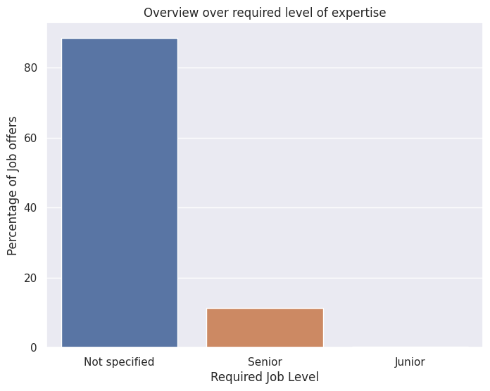

```python
category = 'Level'
fig = plt.subplots(figsize = (8,6))
_ = sns.barplot(x= df[category].value_counts().index,
            y=df[category].value_counts()/df.shape[0]*100,
            hue = df[category].value_counts().index)
plt.title('Overview over required level of expertise')
plt.ylabel('Percentage of Job offers')
plt.xlabel('Required Job Level');
```

**Key takeaway**: Most positions don't specify the level and only 2 Junior positions are offered of the total 672 entries!

#### 2.2) What are the sectors in which data related jobs are needed?

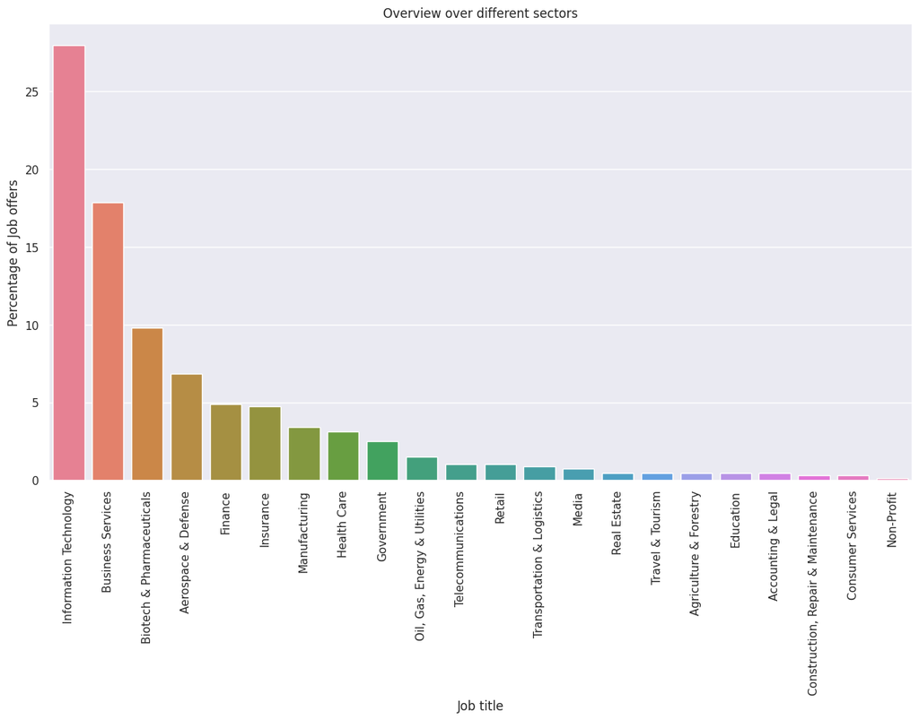

```python
category = 'Sector'
fig = plt.subplots(figsize = (15,8))
_ = sns.barplot(x= df[category].value_counts().index,
            y=df[category].value_counts()/df.shape[0]*100,
            hue = df[category].value_counts().index)
plt.title('Overview over different sectors')
plt.ylabel('Percentage of Job offers')
plt.xlabel('Job title')
plt.xticks(rotation=90);
```

**Key takeaway**: The field of data spans throughout a vast number of sectors. IT, Business Services and Biotech & Pharmaceuticals make up for over 50 % of the job market.

#### 2.3) What are the industries in which data related jobs are needed? What are the top industries?

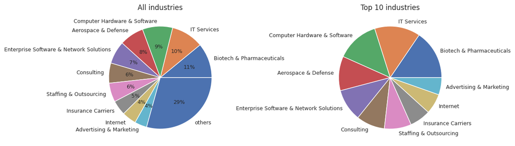

```python
#extract sorted Industry information from dataframe
df_industry = df['Industry'].value_counts().to_frame().reset_index().sort_values('count', ascending = False)
df_top_industries = df_industry[:10].copy() #extract only the top 10 industries
#summarize the other industries under 'others'
new_row = pd.DataFrame(data = {
    'Industry' : ['others'],
    'count' : [df_industry['count'][10:].sum()]
})
df_industry_compact = pd.concat([df_top_industries, new_row]) #combine new dataframe for a more compact representation
#plotting
fig, axes = plt.subplots(nrows = 1, ncols = 2, figsize = (13,4))
#all industries
df_industry_compact.plot(kind = 'pie', y = 'count',autopct='%1.0f%%', labels = df_industry_compact['Industry'], ax = axes[0],label='',textprops={'fontsize': 9})
axes[0].set_title('All industries')
axes[0].get_legend().remove()
#top 10 industries
df_top_industries.plot(kind = 'pie', y = 'count', labels = df_top_industries['Industry'], ax = axes[1],label='',textprops={'fontsize': 9})
axes[1].set_title('Top 10 industries')
axes[1].get_legend().remove()
```

**Key takeaway**: The top 10 (of 58) industries make up for 70 % of the job postings. These industries share have a fairly even share. Biotech & Pharmaceuticals and IT Services offer the most jobs.

#### 2.4) What job titles are most desired?

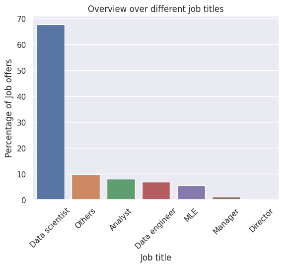

```python
_ = sns.barplot(x= df["Job Title simplyfied"].value_counts().index,
            y=df["Job Title simplyfied"].value_counts()/df.shape[0]*100,
            hue = df["Job Title simplyfied"].value_counts().index)
plt.title('Overview over different job titles')
plt.ylabel('Percentage of Job offers')
plt.xlabel('Job title')
plt.xticks(rotation=45);
```

**Key takeaway**: Most data related postions are Data scientists, covering more than 65 % of the data set

#### 2.5) What are the most desired requirements?

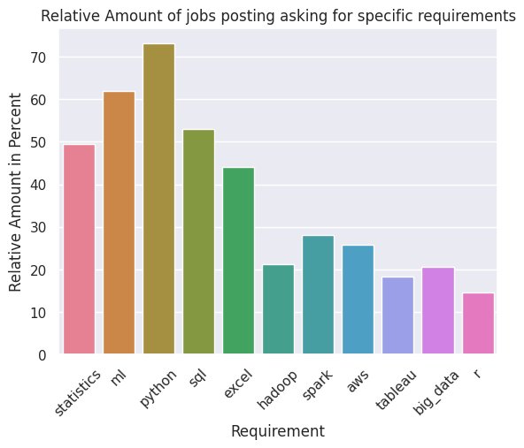

```python
requirements = ['statistics','ml', 'python','sql', 'excel', 'hadoop', 'spark',
       'aws', 'tableau', 'big_data',  'r']
sns.barplot(x=requirements,
            y=df[requirements].mean()*100,
            hue = df[requirements].mean().index)
plt.title('Relative Amount of jobs posting asking for specific requirements')
plt.ylabel('Relative Amount in Percent')
plt.xlabel('Requirement')
plt.xticks(rotation=45);
```

**Key takeaway**: Python and machine learning are the most popular requirement for data related postions, covering over 70 % and 60 % of the postings respecively. SQL and statistics are required by around half of the job postings. Indicated by the requirement hadoop, spark and big_data, the industry starts to require more and more knowledge about big data. Yet, there is still a high demand for excel which does not cope well with large data sets

#### 2.6) Which states have the most offered positions?

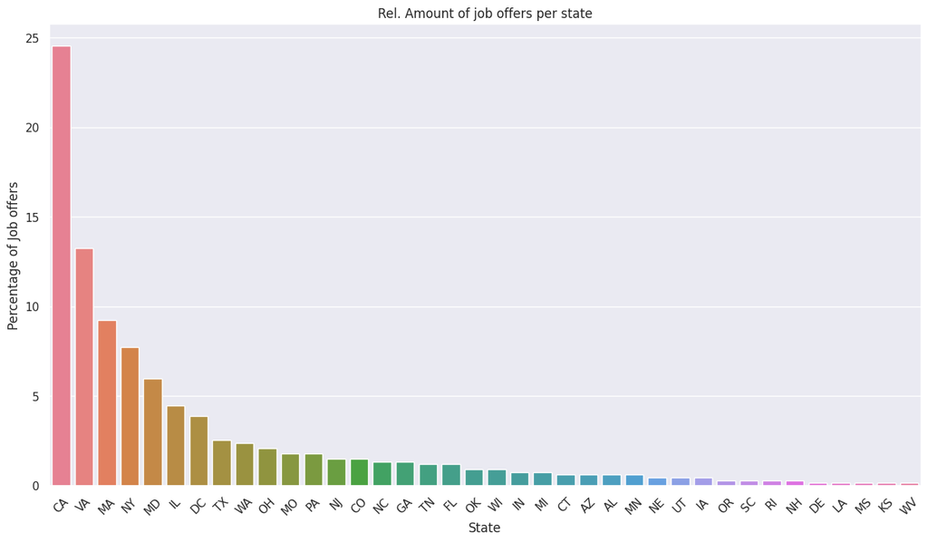

```python
fig = plt.subplots(figsize = (15,8))
_ = sns.barplot(x= df["State"].value_counts().index,
            y=df["State"].value_counts()/df.shape[0]*100,
            hue = df["State"].value_counts().index)
plt.title('Rel. Amount of job offers per state')
plt.ylabel('Percentage of Job offers')
plt.xlabel('State')
plt.xticks(rotation=45);
```

**Key takeaway**: Almost a quarter of all jobs postings are located in California

#### 2.7) A deep dive on California:

Let's take a deep dive on California. This is of personal interest, as I live in Pasadena.

##### 2.7.1) What cities in California offer the most positions?

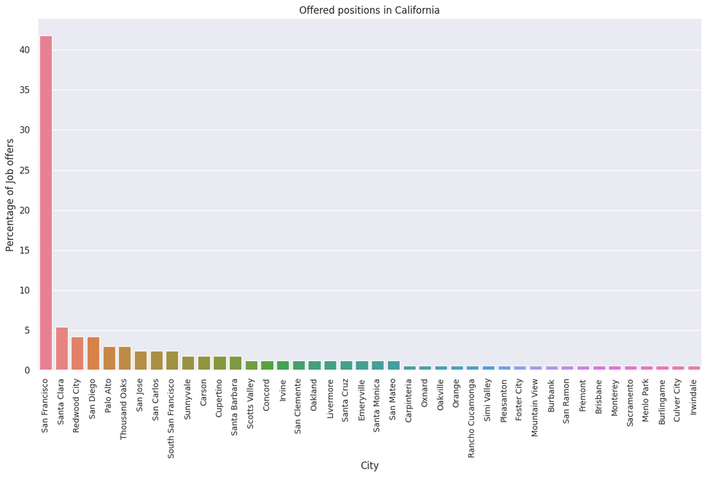

```python
df_ca = df[df['State'] == 'CA'] #extract data with locations in California

fig = plt.subplots(figsize = (15,8))
ax = sns.barplot(x= df_ca["City"].value_counts().index,
            y=df_ca["City"].value_counts()/df_ca.shape[0]*100,
            hue = df_ca["City"].value_counts().index)
ax.set_xticklabels(ax.get_xticklabels(), fontsize=10)
plt.title('Offered positions in California')
plt.ylabel('Percentage of Job offers')
plt.xlabel('City')
plt.xticks(rotation=90);
```

There are alot of job postings in San Fransisco. The comparison to other cities is lacking, as the city Los Angeles is not even listed, rather the neighborhoods. The job distribution is better analyzed using geospatial on a map.

##### 2.7.2) What are the companies in the LA region?

To create a map, the coordinated for the cities in California are needed.

```python
# load the coordiate data
city_df = pd.read_csv("./data/citynames_coords.csv")
# split coordinates in lateral and longitudinal coordinates
city_df['lat'] = city_df['lat long'].map(lambda x: float(x.split(',')[0]))
city_df['long'] = city_df['lat long'].map(lambda x: float(x.split(',')[1]))
city_df.drop(columns='lat long', inplace=True)
#left join the coordinated onto the California data set df_ca
df_ca = df_ca.merge(city_df, on= 'City',how='left')
# created jittered coordinates for a better representation on the heat map
df_ca['lat_jittered'] = df_ca['lat'] + np.random.uniform(-0.03,0.03,len(df_ca['lat']))
df_ca['long_jittered'] = df_ca['long']+ np.random.uniform(-0.03,0.03,len(df_ca['lat']))
```

```python
map = folium.Map(location=(37,-119.33), zoom_start=5)
feature_group = folium.FeatureGroup("Locations")
#add marker for every job posting
for ind in df_ca.index:
    feature_group.add_child(
        folium.CircleMarker(
            location= [df_ca['lat_jittered'][ind],df_ca['long_jittered'][ind]],
            tooltip=df_ca['Company Name'][ind],
            popup=df_ca['Company Name'][ind] + ' ' + df_ca['Job Title'][ind],
            radius =1
    ))
map.add_child(feature_group)
#created a heat map to visualize job posting density
heat_data=list(zip(df_ca.lat_jittered, df_ca.long_jittered))
from folium.plugins import HeatMap
HeatMap(heat_data).add_to(map)
map
```

Make this Notebook Trusted to load map: File -> Trust Notebook

[interactive chart not shown]

**Key takeaway**: The map shows how the job postings in California can be clustered in two larger areas: the greater area of San Fransisco and greater area of Los Angeles. San Fransisco shows a much higher job density. Potential employers in L.A. are Evolvinc, AccessHope, Dermalogica, DirectAgents and Edmunds.com.

#### 2.8) A closer look on salaries:

Let's take a closer look on the salaries as one on few numerical features in this data set.

**Note**: The "Salary Average" describes the midpoint of the posted salary range on Glass Door. Every salary analysis uses this feature instead of the salary range. To avoid ambiguity, the word "average" is only used to describe the feature "Salary Average". The word "Mean" is used if the mean function is applied to the "Salary Average".

##### 2.8.1) What are the average salaries across states?

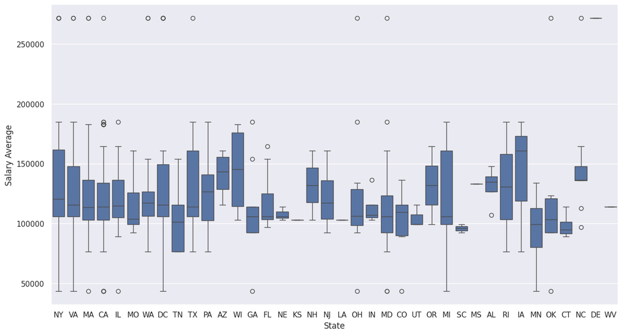

```python
fig = plt.subplots(figsize = (15,8))
sns.boxplot(data=df, x = "State", y = "Salary Average")
```

**Key takeaway**: The data ordered by states contains the alot of outliers, indicating that the median is a better statistic than the mean. The median income across states is with few exceptions remains in a relatively small band between 105K and 140K, compared to vastly varying average costs of livings across the states.

##### 2.8.2) What are the average salaries across the different job titles?

A simple pivot table already shows that the mean of the Salary Average does not differ greatly for different job titles. The different between the highest (manager) and the lowest (data engineer) is only around $19000.

```python
#create a pivot table to analyse the mean of salary average
#rename column to avoid ambiguity
pd.pivot_table(df,
            index='Job Title simplyfied',
            values='Salary Average').rename(
                columns={'Salary Average': 'Mean Salary Average'})
```

| Job Title simplyfied | Mean Salary Average |
| --- | --- |
| Analyst | 115718.181818 |
| Data engineer | 113808.510638 |
| Data scientist | 125216.483516 |
| Director | 127333.333333 |
| MLE | 118986.842105 |
| Manager | 132500.000000 |
| Others | 128053.030303 |

##### 8.3) Does the required programming language affect salaries?

R is usually more frequently used in academia and research as opposed to industry positions. So there could be a difference in salaries according to the required programming language.

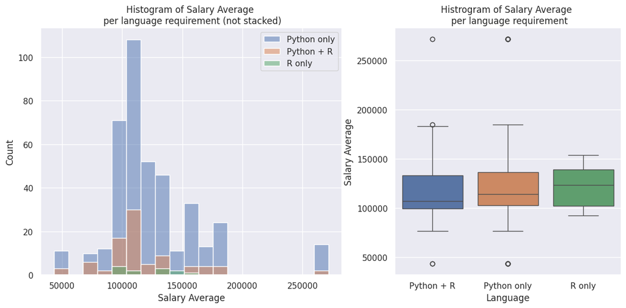

```python
# create list of languages
language_list = ['Python only', 'Python + R','R only']
# excludes unspecified not in list
df_lang = df[df['Language'].isin(language_list)]
# set number of bins
n_bins = 20
# create unified bins for histplots
bins = np.linspace(df_lang['Salary Average'].min(), df_lang['Salary Average'].max(), n_bins)
# plotting histograms
fig, axes = plt.subplots(nrows = 1, ncols = 2, figsize = (14,6),gridspec_kw={'width_ratios': [2, 1.5]})
sns.histplot(x=df[df['Language']=='Python only']['Salary Average'],alpha =0.5, bins = bins, ax = axes[0],label = 'Python only')
sns.histplot(x=df[df['Language']=='Python + R']['Salary Average'],alpha =0.5, bins = bins, ax = axes[0],label = 'Python + R')
sns.histplot(x=df[df['Language']=='R only']['Salary Average'],alpha =0.5, bins = bins, ax = axes[0],label = 'R only')

# plotting boxplot
ax = sns.boxplot(data=df_lang, x='Language', y='Salary Average', hue='Language', ax = axes[1])

axes[0].set_title('Histogram of Salary Average \n per language requirement (not stacked)')
axes[0].legend()
axes[1].set_title('Histrogram of Salary Average \n per language requirement')
```

**Key takeaway**: Salaries Averages include alot of observations classified as outliers. This makes the median a more suitable statistic that the mean to summarizes the salaries. Suprisingly, the median salary average is highest for the language requirement of only R. Yet, in this category there are the least amount of observations.

##### 2.8.4) Is there a realtionship between salaries and the sector?

```python
# create a pivot table to store the number of observations per sector
pt_sector = pd.pivot_table(data = df,index='Sector', values = 'Salary Average', aggfunc=['mean','count']).sort_values(('mean','Salary Average'),ascending=False)
# create a list of counts
count_list = pt_sector[('count','Salary Average')].to_list()

pt_sector
```

| Sector | mean Salary Average | count Salary Average |
| --- | --- | --- |
| Consumer Services | 203750.000000 | 2 |
| Media | 155300.000000 | 5 |
| Retail | 150142.857143 | 7 |
| Government | 134470.588235 | 17 |
| Aerospace & Defense | 132695.652174 | 46 |
| Business Services | 130079.166667 | 120 |
| Travel & Tourism | 128666.666667 | 3 |
| Accounting & Legal | 124666.666667 | 3 |
| Manufacturing | 123239.130435 | 23 |
| Biotech & Pharmaceuticals | 122871.212121 | 66 |
| Health Care | 119761.904762 | 21 |
| Information Technology | 118909.574468 | 188 |
| Education | 117833.333333 | 3 |
| Transportation & Logistics | 117750.000000 | 6 |
| Real Estate | 116833.333333 | 3 |
| Finance | 115500.000000 | 33 |
| Telecommunications | 112357.142857 | 7 |
| Insurance | 111281.250000 | 32 |
| Agriculture & Forestry | 103833.333333 | 3 |
| Oil, Gas, Energy & Utilities | 101300.000000 | 10 |
| Construction, Repair & Maintenance | 74750.000000 | 2 |
| Non-Profit | 43500.000000 | 1 |

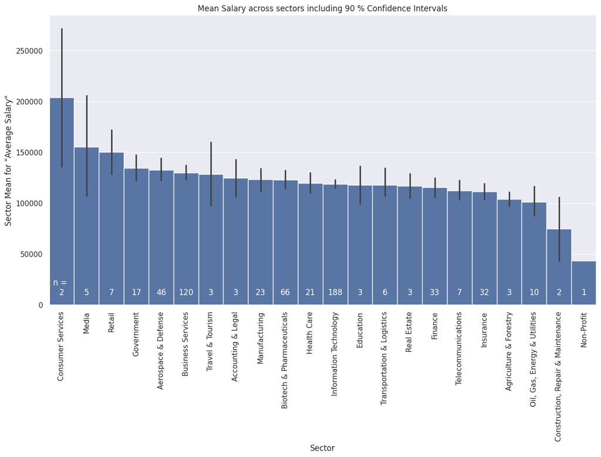

```python
fig = plt.subplots(figsize = (15,8))
# create a bar plot of mean of salary average including 90 % confidence intervals
sns.barplot(data = df, x='Sector',y='Salary Average',
            errorbar=('ci',90),
            width=1,
            order=pt_sector.index)
ax.set_xticklabels(ax.get_xticklabels(), fontsize=10)
plt.title('Mean Salary across sectors including 90 % Confidence Intervals')
plt.ylabel('Sector Mean for "Average Salary"')
plt.xlabel('Sector')
plt.xticks(rotation=90);
#include number of observations at bottom of bars
for i in range(len(count_list)):
    plt.text(x = i , y = 10000, s = count_list[i], size = 12,horizontalalignment = 'center', color = 'w')
# add 'n='
plt.text(x = 0 , y = 10000, s = "n = \n", size = 12,horizontalalignment = 'center', color = 'w')
```

**Key takeaway**: The average income is very similar between the different sectors at around 120K. Customer Services and Media (on the high end) and Construction, Repair & Maintance and Non-Profit (on the low end) deviate alot from the other sectors, and have a higher uncertainty indicated by the lower sample size n or the the confidence interval.

#### 2.9) Miscellaneous:

##### 2.9.1) Is there more information to uncover from the job descriptions?

The most information about the job postings are stored in the job description. One-hot encoded features for job requirements have been created. Maybe creating a word cloud helps to identify more job requirments.

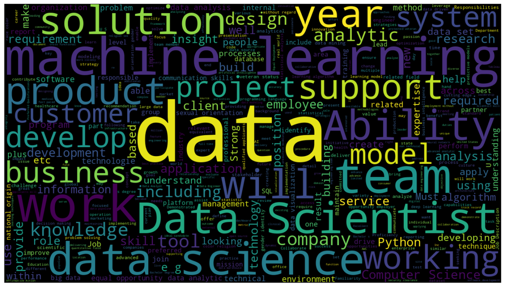

```python
# create a custom list of stop words
stop_words = list(STOPWORDS)
custom_stop_words = ['experience','user', 'need']
stop_words = set(stop_words + custom_stop_words)
# combine all job descriptions
words = " ".join(df['Job Description'])
# create a word cloud
wordcloud = WordCloud(max_words=400, width =1280, height = 720, background_color="black",stopwords=stop_words).generate(words)
plt.figure(figsize=[15,15])
plt.imshow(wordcloud, interpolation="bilinear")
plt.axis('off')
plt.savefig('wordcloud.png');
```

**Key takeaway**: Machine learning is a word that is very frequent in the job descriptions. After analysing the word cloud, a one-hot encoded feature has been created, which was very sought after job requirement, as shown in earlier analyses. Word like model, analytic, develop, support and solution speak for the problem solving mentality that is needed in the field of data science.

##### 2.9.2) Are there any other relationships in the data set?

Usually done earlier on in the analysis, a pair plot of the features can be created to detect trends in the data set. This is paired with a heat map of the correlation coefficients.

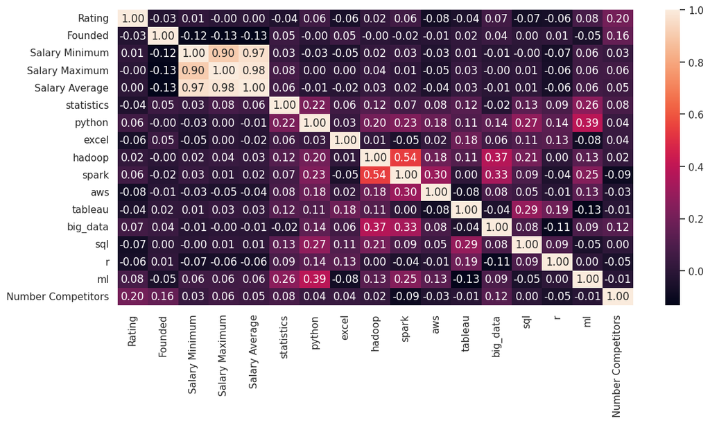

```python
#heat map of the correlation coefficients
plt.figure(figsize=(13, 6))
sns.heatmap(df.corr(numeric_only=True),annot=True,fmt=".2f")
```

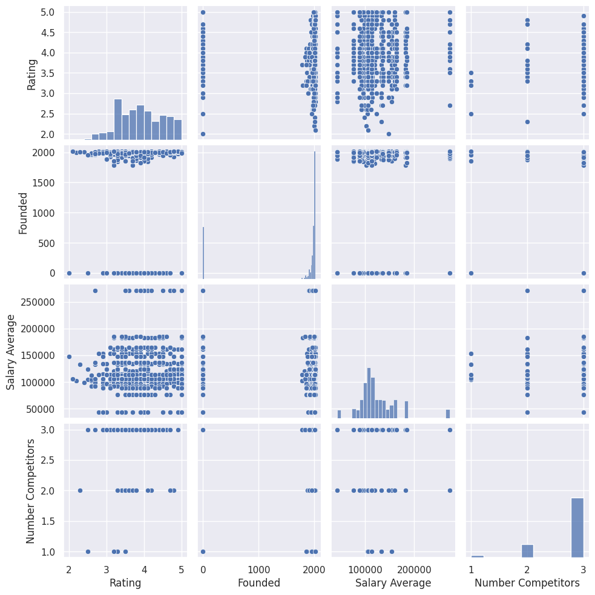

```python
features = ['Rating','Founded','Salary Average','Number Competitors']
sns.pairplot(data=df[features])
```

**Key takeaway**: There is no strong correlations worth investigating any further. The strong correlation between the salary features is a result of the feature engineering. Some keywords pairs like spark/hadoop and big_data/hadoop seem to appear more often together.

## Summary

During this project, a data set about job postings scraped from Glassdoor has been analyzed. Due to the nature of the data set, the focus was on the exploratory analysis as the possibilities for building models was very limited. At first the data was cleaned and features were created. Depending on the question at hand, a appropriate tool for visualization has been chosen including bar plots, word maps, interactive geospatial maps, and pie charts.

## Outlook

There are few things I like to get back to once times allows it:

- I would like to identify whether job requirements like Machine Learning can drive mean salaries using hypothesis testing. On-hot encoded features devide the data set in two partitions, which would be a good basis for the application of hypothesis testing.
- I would like to further improve on my dash boarding skills. This data set and its EDA is a good starting point.

[Return to Portfolio Page](https://sebastianghafafian.github.io/Portfolio/)